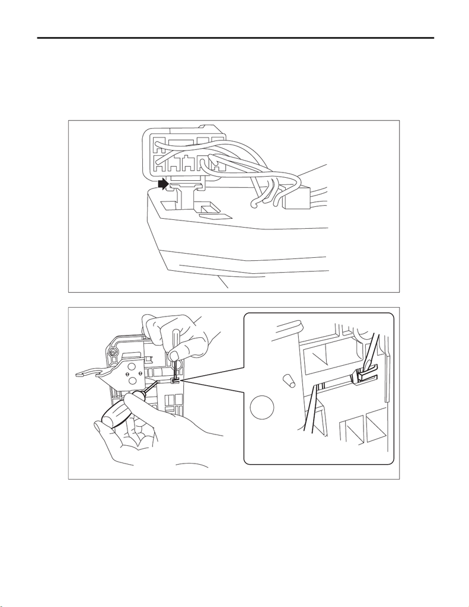

CS-50

AT Shift Lock Solenoid and “P” Range Switch

CONTROL SYSTEMS

5. AT Shift Lock Solenoid and “P” Range Switch

A: REMOVAL

1. SOLENOID UNIT

1) Remove the AT select lever. <Ref. to CS-24, REMOVAL, Select Lever.>

2) Remove the spacer and gasket. <Ref. to CS-31, DISASSEMBLY, Select Lever.>

3) Using a flat tip screwdriver with a thin tip, remove the harness connector.

4) Raise the claw with a flat tip screwdriver with a thin tip and remove the solenoid unit.

CS-01107

CS-01139

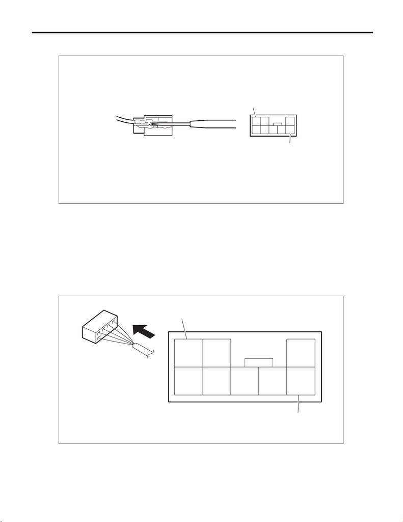

AT Shift Lock Solenoid and “P” Range Switch

CONTROL SYSTEMS

5) Remove the terminal of the solenoid unit using a flat tip precision screwdriver with a tip width of 1.3 mm

(0.05 in) or less, KTC connector terminal tool ECC-1T or equivalent.

2. “P” RANGE SWITCH

For the removal of “P” range switch, refer to the procedure for AT select lever. <Ref. to CS-31, DISASSEM-

BLY, Select Lever.>

B: INSTALLATION

Install in the reverse order of removal.

NOTE:

Connect the solenoid unit terminals.

(A) Solenoid unit terminals

(A) Solenoid unit (color code: blue) (B) Solenoid unit (color code: black)

CS-01110

87

21

65

4

(A)

(A)

CS-01551

87

21

65

4

(B)

(A)

[figure not shown]

CS-52

AT Shift Lock Solenoid and “P” Range Switch

CONTROL SYSTEMS

C: INSPECTION

1 CHECK SOLENOID UNIT.

Measure the resistance of solenoid unit con-

nector terminals.

Terminals

No. 4 — No. 3:

Is the resistance 27.6 — 30.5

Ω?

Go to step 2. Replace the sole-

noid unit. <Ref. to

CS-50, AT Shift

Lock Solenoid and

“P” Range

Switch.>

2 CHECK SOLENOID UNIT.

Connect the battery to the solenoid unit connec-

tor terminals, and then operate the solenoid.

Terminals

No. 3 (+) — No. 4 (–):

Does the solenoid unit operate

normally?

Go to step 3. Replace the sole-

noid unit. <Ref. to

CS-50, AT Shift

Lock Solenoid and

“P” Range

Switch.>

3 CHECK “P” RANGE SWITCH.

1) Shift the select lever to “P” range.

2) Measure the resistance between “P” range

switch connector terminals.

Terminals

No. 1 — No. 2:

Is the resistance less than 1 Ω? Go to step 4. Replace the “P”

range switch. <Ref.

to CS-50, AT Shift

Lock Solenoid and

“P” Range

Switch.>

4 CHECK “P” RANGE SWITCH.

1) Set the select lever to other than “P” range.

2) Measure the resistance between “P” range

switch connector terminals.

Terminals

No. 1 — No. 2:

Is the resistance 1 MΩ or

more?

Normal Replace the “P”

range switch. <Ref.

to CS-50, AT Shift

Lock Solenoid and

“P” Range

Switch.>